```python
# Import required libraries

import pandas as pd
import numpy as np
import matplotlib.pyplot as plt
import seaborn as sns
from sklearn.model_selection import train_test_split
from sklearn.preprocessing import StandardScaler, OneHotEncoder, MinMaxScaler
from sklearn.metrics import classification_report, confusion_matrix, roc_curve, precision_recall_curve, auc
from sklearn.model_selection import GridSearchCV
from sklearn.ensemble import RandomForestClassifier, GradientBoostingClassifier
from sklearn.linear_model import LogisticRegression
from sklearn.svm import SVC
from sklearn.metrics import accuracy_score, precision_score, recall_score, f1_score, roc_auc_score
from scipy.stats import chi2_contingency, f_oneway
```

# Data reading and observation

```python
# Load the dataset
dataset = pd.read_csv('/content/sample_data/credit.csv')

# Observe the data by printing top 5 rows
dataset.head()
```

|  | checking_balance | months_loan_duration | credit_history | purpose | amount | savings_balance | employment_duration | percent_of_income | years_at_residence | age | other_credit | housing | existing_loans_count | job | dependents | phone | default |
| --- | --- | --- | --- | --- | --- | --- | --- | --- | --- | --- | --- | --- | --- | --- | --- | --- | --- |
| 0 | < 0 DM | 6 | critical | furniture/appliances | 1169 | unknown | > 7 years | 4 | 4 | 67 | none | own | 2 | skilled | 1 | yes | no |
| 1 | 1 - 200 DM | 48 | good | furniture/appliances | 5951 | < 100 DM | 1 - 4 years | 2 | 2 | 22 | none | own | 1 | skilled | 1 | no | yes |
| 2 | unknown | 12 | critical | education | 2096 | < 100 DM | 4 - 7 years | 2 | 3 | 49 | none | own | 1 | unskilled | 2 | no | no |
| 3 | < 0 DM | 42 | good | furniture/appliances | 7882 | < 100 DM | 4 - 7 years | 2 | 4 | 45 | none | other | 1 | skilled | 2 | no | no |
| 4 | < 0 DM | 24 | poor | car | 4870 | < 100 DM | 1 - 4 years | 3 | 4 | 53 | none | other | 2 | skilled | 2 | no | yes |

```python
# Print columns
dataset.columns
```

```
Index(['checking_balance', 'months_loan_duration', 'credit_history', 'purpose',
       'amount', 'savings_balance', 'employment_duration', 'percent_of_income',
       'years_at_residence', 'age', 'other_credit', 'housing',
       'existing_loans_count', 'job', 'dependents', 'phone', 'default'],
      dtype='object')
```

# Data Exploration and Visualization

```python
# Print Summary Statistics
print("Summary Statistics:")
dataset.describe(include = 'all')
```

```
Summary Statistics:
```

|  | checking_balance | months_loan_duration | credit_history | purpose | amount | savings_balance | employment_duration | percent_of_income | years_at_residence | age | other_credit | housing | existing_loans_count | job | dependents | phone | default |
| --- | --- | --- | --- | --- | --- | --- | --- | --- | --- | --- | --- | --- | --- | --- | --- | --- | --- |
| count | 1000 | 1000.000000 | 1000 | 1000 | 1000.000000 | 1000 | 1000 | 1000.000000 | 1000.000000 | 1000.000000 | 1000 | 1000 | 1000.000000 | 1000 | 1000.000000 | 1000 | 1000 |
| unique | 4 | NaN | 5 | 6 | NaN | 5 | 5 | NaN | NaN | NaN | 3 | 3 | NaN | 4 | NaN | 2 | 2 |
| top | unknown | NaN | good | furniture/appliances | NaN | < 100 DM | 1 - 4 years | NaN | NaN | NaN | none | own | NaN | skilled | NaN | no | no |
| freq | 394 | NaN | 530 | 473 | NaN | 603 | 339 | NaN | NaN | NaN | 814 | 713 | NaN | 630 | NaN | 596 | 700 |
| mean | NaN | 20.903000 | NaN | NaN | 3271.258000 | NaN | NaN | 2.973000 | 2.845000 | 35.546000 | NaN | NaN | 1.407000 | NaN | 1.155000 | NaN | NaN |
| std | NaN | 12.058814 | NaN | NaN | 2822.736876 | NaN | NaN | 1.118715 | 1.103718 | 11.375469 | NaN | NaN | 0.577654 | NaN | 0.362086 | NaN | NaN |
| min | NaN | 4.000000 | NaN | NaN | 250.000000 | NaN | NaN | 1.000000 | 1.000000 | 19.000000 | NaN | NaN | 1.000000 | NaN | 1.000000 | NaN | NaN |
| 25% | NaN | 12.000000 | NaN | NaN | 1365.500000 | NaN | NaN | 2.000000 | 2.000000 | 27.000000 | NaN | NaN | 1.000000 | NaN | 1.000000 | NaN | NaN |
| 50% | NaN | 18.000000 | NaN | NaN | 2319.500000 | NaN | NaN | 3.000000 | 3.000000 | 33.000000 | NaN | NaN | 1.000000 | NaN | 1.000000 | NaN | NaN |
| 75% | NaN | 24.000000 | NaN | NaN | 3972.250000 | NaN | NaN | 4.000000 | 4.000000 | 42.000000 | NaN | NaN | 2.000000 | NaN | 1.000000 | NaN | NaN |
| max | NaN | 72.000000 | NaN | NaN | 18424.000000 | NaN | NaN | 4.000000 | 4.000000 | 75.000000 | NaN | NaN | 4.000000 | NaN | 2.000000 | NaN | NaN |

```python
# Seperate numerical and catagorical columns
numerical_columns = ['months_loan_duration', 'amount', 'percent_of_income', 'years_at_residence', 'age', 'existing_loans_count', 'dependents']
categorical_columns = ['checking_balance', 'credit_history', 'purpose', 'savings_balance', 'employment_duration', 'other_credit', 'housing', 'job', 'phone']
```

Univariate Analysis

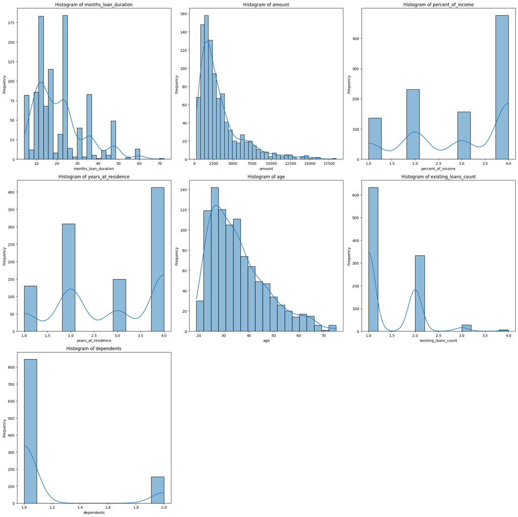

```python
# Histogram for numerical features
fig, axes = plt.subplots(nrows=3, ncols=3, figsize=(20, 20))
# Populate subplots with data
for i, feature in enumerate(numerical_columns):
    if i < len(numerical_columns):  # Ensure there are fewer features than subplots
        ax = axes[i//3, i%3]
        sns.histplot(dataset[feature], kde=True, ax=ax)
        ax.set_title(f'Histogram of {feature}')
        ax.set_xlabel(feature)
        ax.set_ylabel('Frequency')
num_features = len(numerical_columns)
num_empty_plots = 3 * 3 - num_features
for i in range(num_empty_plots):
    fig.delaxes(axes.flatten()[num_features + i])

plt.tight_layout()
plt.show()
```

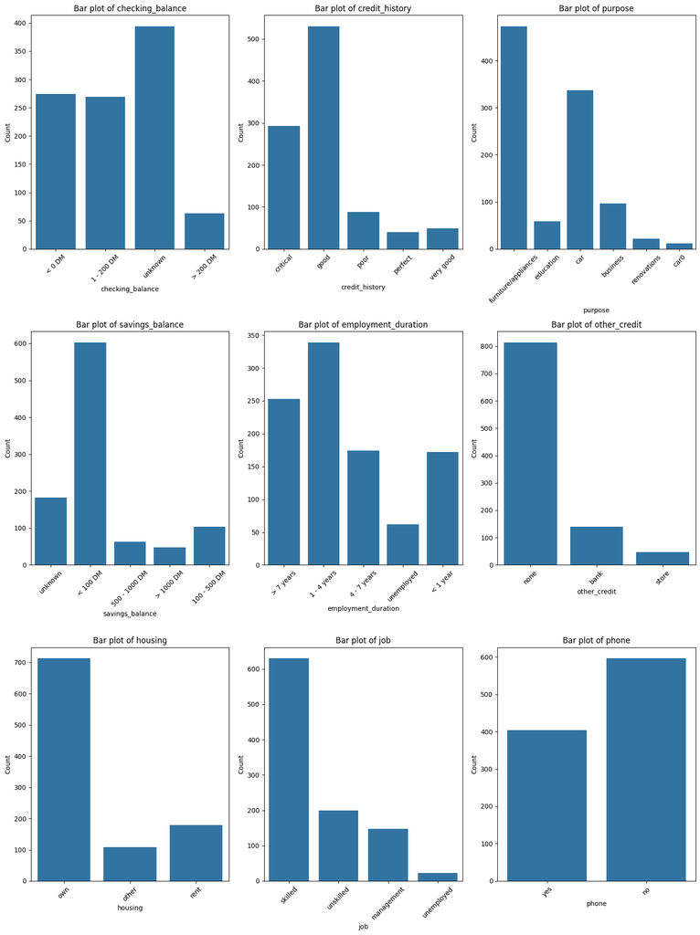

```python
# Bar plot for categorical features
fig, axes = plt.subplots(nrows=3, ncols=3, figsize=(15, 20))

# Populate subplots with data
for i, feature in enumerate(categorical_columns):
    if i < len(categorical_columns):
        ax = axes[i//3, i%3]
        sns.countplot(x=feature, data=dataset, ax=ax)
        ax.set_title(f'Bar plot of {feature}')
        ax.set_xlabel(feature)
        ax.set_ylabel('Count')
        ax.tick_params(axis='x', rotation=45)
num_features = len(categorical_columns)
num_empty_plots = 3 * 3 - num_features
for i in range(num_empty_plots):
    fig.delaxes(axes.flatten()[num_features + i])

plt.tight_layout()
plt.show()
```

**Bivariate Analysis**

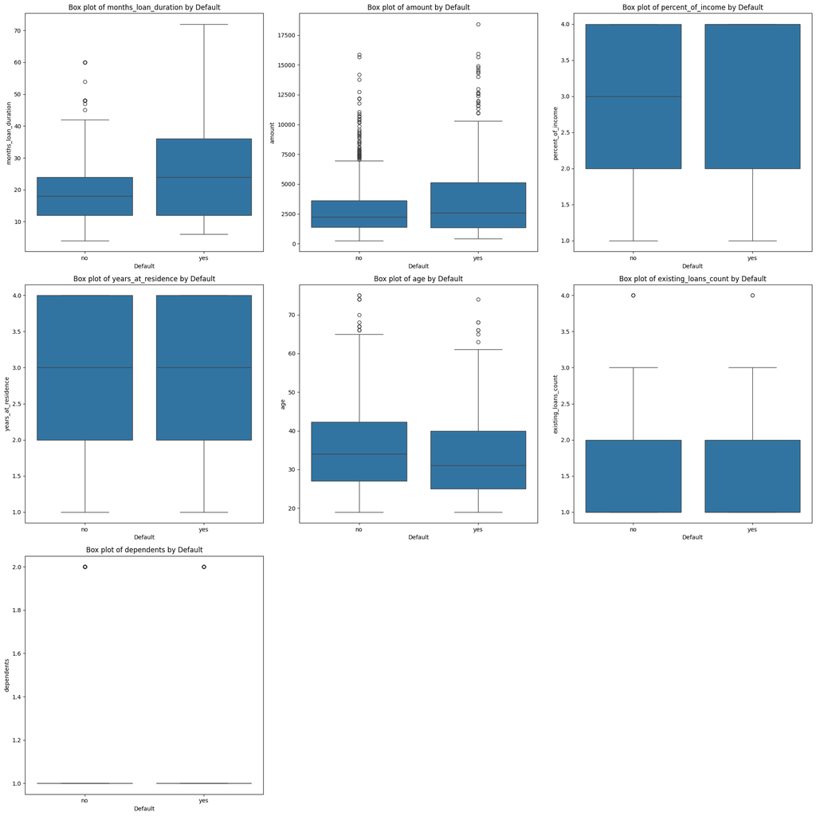

```python
# Box plot for numerical features vs. target variable
num_plots = len(numerical_columns)
fig, axes = plt.subplots(nrows=3, ncols=3, figsize=(20, 20))

# Populate subplots with data
for i, feature in enumerate(numerical_columns):
    if i < num_plots:
        ax = axes[i//3, i%3]
        sns.boxplot(x='default', y=feature, data=dataset, ax=ax)
        ax.set_title(f'Box plot of {feature} by Default')
        ax.set_xlabel('Default')
        ax.set_ylabel(feature)
num_empty_plots = 3 * 3 - num_plots
for i in range(num_empty_plots):
    fig.delaxes(axes.flatten()[num_plots + i])

plt.tight_layout()
plt.show()
```

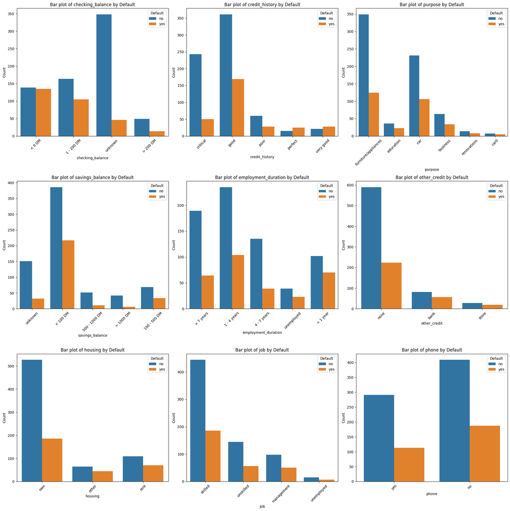

```python
# Bar plot for categorical features vs. target variable
num_plots = len(categorical_columns)
fig, axes = plt.subplots(nrows=3, ncols=3, figsize=(20, 20))

# Populate subplots with data
for i, feature in enumerate(categorical_columns):
    if i < num_plots:
        ax = axes[i//3, i%3]
        sns.countplot(x=feature, hue='default', data=dataset, ax=ax)
        ax.set_title(f'Bar plot of {feature} by Default')
        ax.set_xlabel(feature)
        ax.set_ylabel('Count')
        ax.tick_params(axis='x', rotation=45)
        ax.legend(title='Default', loc='upper right')
num_empty_plots = 3 * 3 - num_plots
for i in range(num_empty_plots):
    fig.delaxes(axes.flatten()[num_plots + i])

plt.tight_layout()
plt.show()
```

```python
# Map 'yes' to 1 and 'no' to 0 in the 'default' column
dataset['default'] = dataset['default'].map({'yes': 1, 'no': 0})
dataset.head()
```

|  | checking_balance | months_loan_duration | credit_history | purpose | amount | savings_balance | employment_duration | percent_of_income | years_at_residence | age | other_credit | housing | existing_loans_count | job | dependents | phone | default |
| --- | --- | --- | --- | --- | --- | --- | --- | --- | --- | --- | --- | --- | --- | --- | --- | --- | --- |
| 0 | < 0 DM | 6 | critical | furniture/appliances | 1169 | unknown | > 7 years | 4 | 4 | 67 | none | own | 2 | skilled | 1 | yes | 0 |
| 1 | 1 - 200 DM | 48 | good | furniture/appliances | 5951 | < 100 DM | 1 - 4 years | 2 | 2 | 22 | none | own | 1 | skilled | 1 | no | 1 |
| 2 | unknown | 12 | critical | education | 2096 | < 100 DM | 4 - 7 years | 2 | 3 | 49 | none | own | 1 | unskilled | 2 | no | 0 |
| 3 | < 0 DM | 42 | good | furniture/appliances | 7882 | < 100 DM | 4 - 7 years | 2 | 4 | 45 | none | other | 1 | skilled | 2 | no | 0 |
| 4 | < 0 DM | 24 | poor | car | 4870 | < 100 DM | 1 - 4 years | 3 | 4 | 53 | none | other | 2 | skilled | 2 | no | 1 |

# Identification of Predictor Variables using Statistical Tests

**Correlation analysis for numerical features**

```python
# Define predictor variables
predictor_from_corr = []
numerical_cols = ['months_loan_duration', 'amount', 'percent_of_income', 'years_at_residence', 'age', 'existing_loans_count', 'dependents', 'default']
# Correlation Analysis
correlation = dataset[numerical_cols].corrwith(dataset['default']).abs().sort_values(ascending=False)
predictor_from_corr.extend(correlation.index[1:4])  # Choose top 3 numerical features with highest absolute correlation

for feature in predictor_from_corr:
    correlation_value = dataset[feature].corr(dataset['default'])
    print(f"{feature} is correlated with default | Correlation: {correlation_value:.4f}")
print('Predictor variables from correlation analysis:', predictor_from_corr) # Print the predictor variables identified from correlation analysis

predictor_from_corr.extend(predictor_from_corr)
```

```
months_loan_duration is correlated with default | Correlation: 0.2149
amount is correlated with default | Correlation: 0.1547
age is correlated with default | Correlation: -0.0911
Predictor variables from correlation analysis: ['months_loan_duration', 'amount', 'age']
```

**ANOVA F-test for numerical features**

```python
# ANOVA F-test (for numerical features)
predictors_anova = []
for feature in numerical_columns:
    f_statistic, p_value = f_oneway(dataset[dataset['default'] == 1][feature], dataset[dataset['default'] == 0][feature])
    if p_value < 0.05:
        predictors_anova.append(feature)
        print(f"{feature} is correlated with default | P-Value: {p_value}")

# Print predictor variables
print("Predictor Variables from Anova F-test:", predictors_anova)
```

```
months_loan_duration is correlated with default | P-Value: 6.488049877187189e-12
amount is correlated with default | P-Value: 8.797572373533373e-07
percent_of_income is correlated with default | P-Value: 0.022035486306960176
age is correlated with default | P-Value: 0.003925339398278295
Predictor Variables from Anova F-test: ['months_loan_duration', 'amount', 'percent_of_income', 'age']
```

among all the predictor variables resulted from Anova test 'percent_of_income' is having a greater p-value i.e. 0.022035486306960176.Also 'percent_of_income' is not resulted from correlation test as a predictor. Taking these observations into account a finalised predictor list from numerical features would be

numerical_predictors = ['months_loan_duration', 'amount', 'age']

**Chi-Square test for categorical features**

```python
# Chi-Square Test
predictors_chi_square = []
categorical_columns = ['checking_balance', 'credit_history', 'purpose', 'savings_balance', 'employment_duration', 'other_credit', 'housing', 'job', 'phone']
for feature in categorical_columns:
    contingency_table = pd.crosstab(dataset[feature], dataset['default'])
    _, p_value, _, _ = chi2_contingency(contingency_table)
    if p_value < 0.05:
        predictors_chi_square.append(feature)
        print(f"{feature} is correlated with default | P-Value: {p_value}")

print('Categorical predictors:', predictors_chi_square)
```

```
checking_balance is correlated with default | P-Value: 1.2189020722893845e-26
credit_history is correlated with default | P-Value: 1.2791872956750918e-12
savings_balance is correlated with default | P-Value: 2.761214238568249e-07
employment_duration is correlated with default | P-Value: 0.0010454523491402541
other_credit is correlated with default | P-Value: 0.0016293178186473534
housing is correlated with default | P-Value: 0.00011167465374597664
Categorical predictors: ['checking_balance', 'credit_history', 'savings_balance', 'employment_duration', 'other_credit', 'housing']
```

```python
numerical_predictors = list(set(predictor_from_corr).intersection(predictors_anova))
categorical_predictors = predictors_chi_square

# Combine the obtained categorical and numerical predictors which strongly correlates with the response variable ('default)
Final_predictors = numerical_predictors + categorical_predictors

# Print the selected predictor variables
print('Selected predicted variables are:', Final_predictors)
```

```
Selected predicted variables are: ['age', 'amount', 'months_loan_duration', 'checking_balance', 'credit_history', 'savings_balance', 'employment_duration', 'other_credit', 'housing']
```

# Data pre-processing

"Now that we have our predictors, it's time to preprocess the data. This involves several steps to ensure our dataset is ready for modeling.

```python
# Observe the data in the selected columns and determine the needed pre-processing

model_data = dataset[Final_predictors]
model_data.head()
```

|  | age | amount | months_loan_duration | checking_balance | credit_history | savings_balance | employment_duration | other_credit | housing |
| --- | --- | --- | --- | --- | --- | --- | --- | --- | --- |
| 0 | 67 | 1169 | 6 | < 0 DM | critical | unknown | > 7 years | none | own |
| 1 | 22 | 5951 | 48 | 1 - 200 DM | good | < 100 DM | 1 - 4 years | none | own |
| 2 | 49 | 2096 | 12 | unknown | critical | < 100 DM | 4 - 7 years | none | own |
| 3 | 45 | 7882 | 42 | < 0 DM | good | < 100 DM | 4 - 7 years | none | other |
| 4 | 53 | 4870 | 24 | < 0 DM | poor | < 100 DM | 1 - 4 years | none | other |

- Columns 'amount', 'age', and 'months_loan_duration' contains non-null numerical data so no pre-processing is needed.whereas all the other columns has categorical data which needs encoding it into numerical values.
- Column 'employment_duration' seems to have ordinal properties since the categories represent different durations of employment, which have a natural order.

  ```
     *   'employment_duration' column needs to be encoded into numerical values, preserving the ordinal relationship.
     *    For ordinal encoding,categories can be mapped to numerical values based on their order.
     *   'unemployed': 1,
         '< 1 year': 2
         '1 - 4 years': 3
         '4 - 7 years': 4
         '> 7 years': 5
  ```

- For the remaining categorical columns one-hot encoding can be utilised to convert to numeric values.

  ```
    *   To achieve this, get_dummies() function from pandas library is to be used. This method allows us to express each category in a column as a binary feature. This procedure generates new binary columns for each of the original categorical columns.
    *   By doing so, we ensure that the categorical data is in a format suitable for machine learning algorithms without establishing any ordinal link between the categories.
  ```

```python
# Define the mapping for ordinal encoding
employment_duration_mapping = {
    'unemployed': 1,
    '< 1 year': 2,
    '1 - 4 years': 3,
    '4 - 7 years': 4,
    '> 7 years': 5
}

# Apply ordinal encoding to the 'employment_duration' column
model_data['employment_duration'] = model_data['employment_duration'].map(employment_duration_mapping)

# Print the data
model_data.head()
```

|  | age | amount | months_loan_duration | checking_balance | credit_history | savings_balance | employment_duration | other_credit | housing |
| --- | --- | --- | --- | --- | --- | --- | --- | --- | --- |
| 0 | 67 | 1169 | 6 | < 0 DM | critical | unknown | 5 | none | own |
| 1 | 22 | 5951 | 48 | 1 - 200 DM | good | < 100 DM | 3 | none | own |
| 2 | 49 | 2096 | 12 | unknown | critical | < 100 DM | 4 | none | own |
| 3 | 45 | 7882 | 42 | < 0 DM | good | < 100 DM | 4 | none | other |
| 4 | 53 | 4870 | 24 | < 0 DM | poor | < 100 DM | 3 | none | other |

```python
# Convert remaining categorical columns to numeric using one-hot encoding
ML_data = pd.get_dummies(model_data, columns=['checking_balance', 'credit_history', 'savings_balance', 'other_credit', 'housing']).astype(int)

# Add preprocessed response i.e.default column
ML_data['default'] = dataset['default']

# Display the updated dataset
ML_data.head()
```

|  | age | amount | months_loan_duration | employment_duration | checking_balance_1 - 200 DM | checking_balance_< 0 DM | checking_balance_> 200 DM | checking_balance_unknown | credit_history_critical | credit_history_good | ... | savings_balance_< 100 DM | savings_balance_> 1000 DM | savings_balance_unknown | other_credit_bank | other_credit_none | other_credit_store | housing_other | housing_own | housing_rent | default |
| --- | --- | --- | --- | --- | --- | --- | --- | --- | --- | --- | --- | --- | --- | --- | --- | --- | --- | --- | --- | --- | --- |
| 0 | 67 | 1169 | 6 | 5 | 0 | 1 | 0 | 0 | 1 | 0 | ... | 0 | 0 | 1 | 0 | 1 | 0 | 0 | 1 | 0 | 0 |
| 1 | 22 | 5951 | 48 | 3 | 1 | 0 | 0 | 0 | 0 | 1 | ... | 1 | 0 | 0 | 0 | 1 | 0 | 0 | 1 | 0 | 1 |
| 2 | 49 | 2096 | 12 | 4 | 0 | 0 | 0 | 1 | 1 | 0 | ... | 1 | 0 | 0 | 0 | 1 | 0 | 0 | 1 | 0 | 0 |
| 3 | 45 | 7882 | 42 | 4 | 0 | 1 | 0 | 0 | 0 | 1 | ... | 1 | 0 | 0 | 0 | 1 | 0 | 1 | 0 | 0 | 0 |
| 4 | 53 | 4870 | 24 | 3 | 0 | 1 | 0 | 0 | 0 | 0 | ... | 1 | 0 | 0 | 0 | 1 | 0 | 1 | 0 | 0 | 1 |

5 rows × 25 columns

# Data Preparation: Splitting into Training and Testing Sets

```python
# Define predictors and target variable
X = ML_data.drop('default', axis=1)
y = ML_data['default']
```

**Standerdization or Normalization?. what to choose?**

Predictors and target variables are all set. But before proceeding with splitting the data into training and testing sets it's best to standertize or normalize the numerical data depending on the nature of data to ensure that all features have the same scale, making the algorithm work effectively.

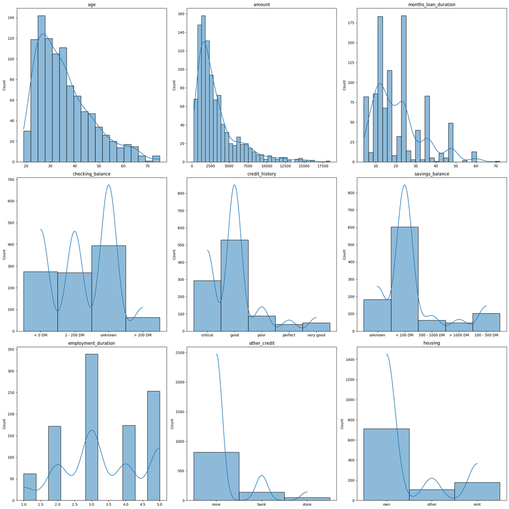

```python
# Let's observe whether the data is guassian distributed

# Plot the distribution
plt.figure(figsize=(20, 20))
for i, col in enumerate(Final_predictors):
    plt.subplot(3, 3, i+1)
    sns.histplot(model_data[col], kde=True)
    plt.title(col)
    plt.xlabel('')
plt.tight_layout()
plt.show()
```

A wave pattern is seen in the histograms, it indicates that data does not follow a guassian distribution.

Given this observation, normalization (MinMaxScaler) would be more appropriate for this dataset, as it does not assume any specific distribution of the data.

```python
# Initialize the MinMaxScaler for normalization
scaler_minmax = MinMaxScaler()

# Normalize numerical features
X_minmax = X.copy()
X_minmax = scaler_minmax.fit_transform(X_minmax)  # Fit and transform the data

# Split the data into training and testing sets (80% train, 20% test)
X_train, X_test, y_train, y_test = train_test_split(X_minmax, y, test_size=0.2, random_state=42)

# Print the shapes of the training and testing sets
print("Training set - Features:", X_train.shape, "Target:", y_train.shape)
print("Testing set - Features:", X_test.shape, "Target:", y_test.shape)
```

```
Training set - Features: (800, 24) Target: (800,)
Testing set - Features: (200, 24) Target: (200,)
```

# Model Training and Evaluation

- Depending on the nature of the data, size of the dataset and the characteristics of data, a model should be choosen.
- "Predicting whether a customer will default or not" is a classification problem. For classification problems like these , Following models can be used.

  ```
      *  Logistic Regression
      *  Decision Trees
      *  Random Forest
      *  Support Vector Machines (SVM)
      *  Gradient Boosting Machines (e.g., XGBoost, LightGBM, CatBoost)
  ```

**Logistic Regression**

```python
# Initialize the Logistic Regression model
model = LogisticRegression()

# Train the model
model.fit(X_train, y_train)

# Make predictions on the test set
y_pred = model.predict(X_test)

# Evaluate the model
accuracy = accuracy_score(y_test, y_pred)
print("Accuracy:", accuracy)
print("\nClassification Report:\n", classification_report(y_test, y_pred))
print("\nConfusion Matrix:\n", confusion_matrix(y_test, y_pred))
```

```
Accuracy: 0.755

Classification Report:
               precision    recall  f1-score   support

           0       0.78      0.90      0.84       141
           1       0.63      0.41      0.49        59

    accuracy                           0.76       200
   macro avg       0.71      0.65      0.67       200
weighted avg       0.74      0.76      0.74       200


Confusion Matrix:
 [[127  14]
 [ 35  24]]
```

**Observations:**

*Accuracy* The Logistic Regression model has an accuracy of about 0.755, which means it properly predicts customers' default statuses 75.5% of the time.

*Precision:*  
Precision for class 0 (non-defaulters) is 0.78, indicating that 78% of customers predicted as non-defaulters are indeed non-defaulters. The precision for class 1 (defaulters) is 0.63, indicating that 63% of the customers projected as defaulters are in fact defaulters. Class 0 has a recall of 0.90, indicating that 90% of non-defaulters are properly anticipated.

*Recall:*  
Class 0 has a recall of 0.90, indicating that 90% of non-defaulters are properly anticipated. The recall for class 1 is 0.41, which means that 41% of the actual defaulters were properly predicted as defaulters.

*F1-score:*  
The F1-score represents the harmonic mean of precision and recall. It strikes a balance between precision and recall.

Overall, the model appears to perform pretty well. However, given the class imbalance (more non-defaulters than defaulters), other evaluation measures like the ROC-AUC score or the precision-recall curve must be looked at.

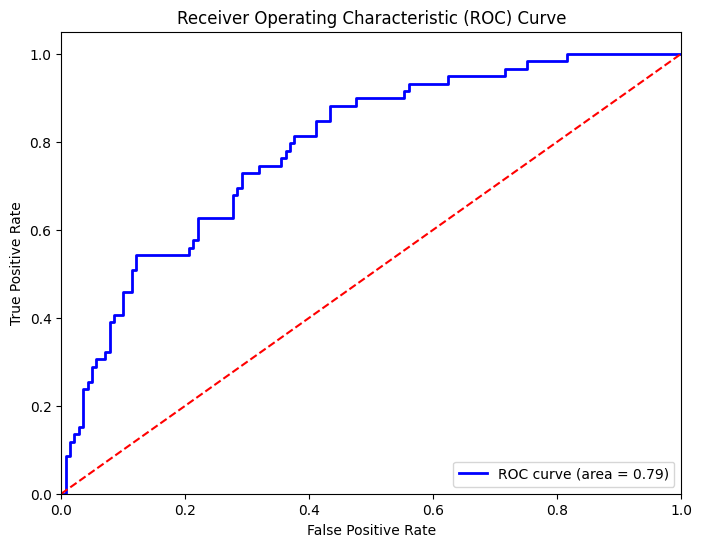

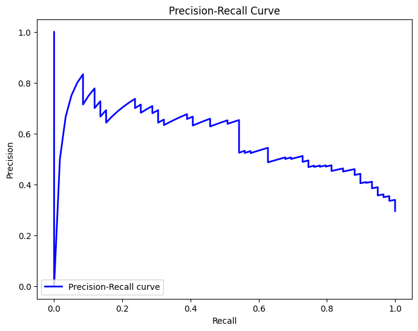

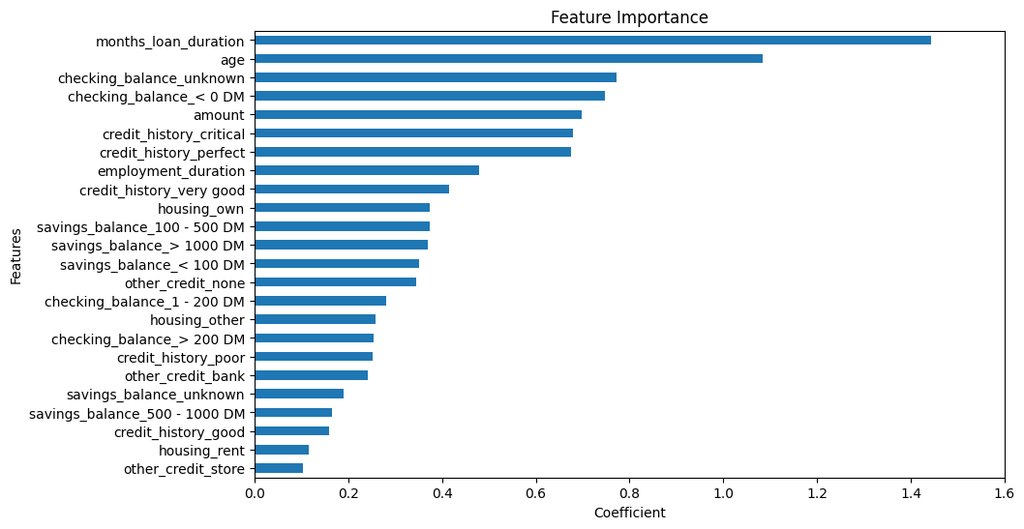

```python
# Plot ROC curve
fpr, tpr, thresholds = roc_curve(y_test, model.predict_proba(X_test)[:, 1])
roc_auc = auc(fpr, tpr)

plt.figure(figsize=(8, 6))
plt.plot(fpr, tpr, color='blue', lw=2, label='ROC curve (area = %0.2f)' % roc_auc)
plt.plot([0, 1], [0, 1], color='red', linestyle='--')
plt.xlim([0.0, 1.0])
plt.ylim([0.0, 1.05])
plt.xlabel('False Positive Rate')
plt.ylabel('True Positive Rate')
plt.title('Receiver Operating Characteristic (ROC) Curve')
plt.legend(loc="lower right")
plt.show()

# Plot Precision-Recall curve
precision, recall, thresholds = precision_recall_curve(y_test, model.predict_proba(X_test)[:, 1])

plt.figure(figsize=(8, 6))
plt.plot(recall, precision, color='blue', lw=2, label='Precision-Recall curve')
plt.xlabel('Recall')
plt.ylabel('Precision')
plt.title('Precision-Recall Curve')
plt.legend(loc="lower left")
plt.show()

# Plot feature importance
coef = model.coef_[0]
feature_importance = pd.Series(coef, index=X.columns)
feature_importance_abs = feature_importance.abs()  # Taking absolute values
feature_importance_abs.sort_values(ascending=True, inplace=True)  # Sort the absolute feature importance values
feature_importance_abs.plot(kind='barh', figsize=(10, 6))  # Use barh for horizontal bar plot
plt.title('Feature Importance')
plt.xlabel('Coefficient')
plt.ylabel('Features')
plt.xticks(np.arange(0, max(feature_importance_abs) + 0.2, 0.2))  # Set custom ticks on the x-axis
plt.show()
```

**Observations**

1. A rough ROC curve suggests that the model's performance may not be optimal. A curve that is mainly above the diagonal line (the line that passes through the origin) indicates that the model outperforms random, but it may not distinguish well between the positive and negative categories.To improve the ROC curve, different algorithms can be given a try.
2. precision-recall curve begins at (0, 1) and declines to (0, 0) before growing and becoming rough indicates that the model initially predicts all instances as positive, resulting in perfect recall but not so good accuracy. This behavior occurs when the model is too optimistic and forecasts everything as positive.

**Random forest classifier**

```python
# Initialize the Random Forest Classifier
RF_model = RandomForestClassifier(n_estimators=100, random_state=42)

# Train the model
RF_model.fit(X_train, y_train)

# Make predictions
RF_y_pred = RF_model.predict(X_test)

# Evaluate the model
RF_accuracy = accuracy_score(y_test, RF_y_pred)
print("Random Forest Classifier Accuracy:", RF_accuracy)
print("\nClassification Report:")                # Classification Report
print(classification_report(y_test, RF_y_pred))
print("\nConfusion Matrix:")                     # Confusion Matrix
print(confusion_matrix(y_test, RF_y_pred))
```

```
Random Forest Classifier Accuracy: 0.77

Classification Report:
              precision    recall  f1-score   support

           0       0.80      0.90      0.85       141
           1       0.66      0.46      0.54        59

    accuracy                           0.77       200
   macro avg       0.73      0.68      0.69       200
weighted avg       0.76      0.77      0.76       200


Confusion Matrix:
[[127  14]
 [ 32  27]]
```

The Random Forest Classifier outperformed the Logistic Regression model. However, there is still room for improvement in the model, particularly in terms of recall for positive classes.

let's do some plotting to provide insights into feature importances and the model's performance Thereby making informed decisions about threshold selection.

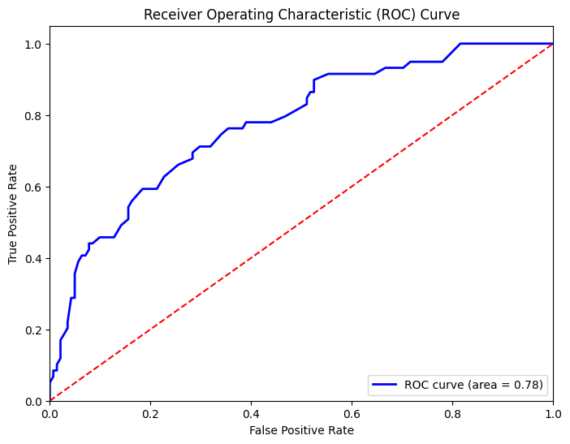

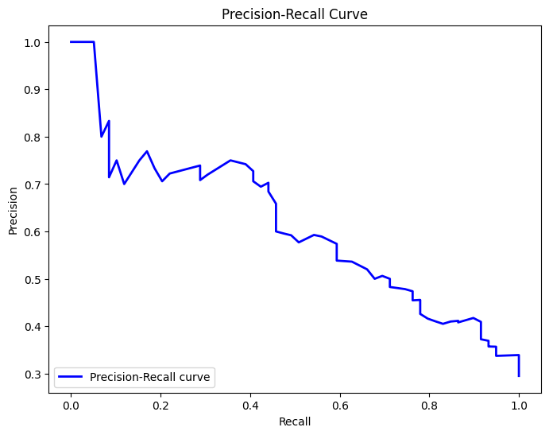

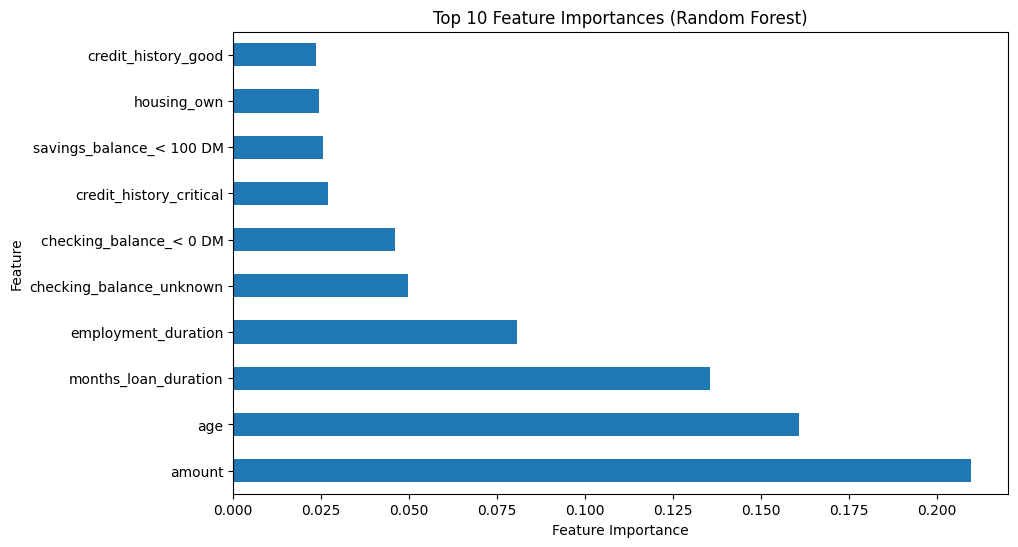

```python
# Plot ROC curve
fpr, tpr, thresholds = roc_curve(y_test, RF_model.predict_proba(X_test)[:, 1])
roc_auc = auc(fpr, tpr)

plt.figure(figsize=(8, 6))
plt.plot(fpr, tpr, color='blue', lw=2, label='ROC curve (area = %0.2f)' % roc_auc)
plt.plot([0, 1], [0, 1], color='red', linestyle='--')
plt.xlim([0.0, 1.0])
plt.ylim([0.0, 1.05])
plt.xlabel('False Positive Rate')
plt.ylabel('True Positive Rate')
plt.title('Receiver Operating Characteristic (ROC) Curve')
plt.legend(loc="lower right")
plt.show()

# Plot Precision-Recall curve
precision, recall, thresholds = precision_recall_curve(y_test, RF_model.predict_proba(X_test)[:, 1])

plt.figure(figsize=(8, 6))
plt.plot(recall, precision, color='blue', lw=2, label='Precision-Recall curve')
plt.xlabel('Recall')
plt.ylabel('Precision')
plt.title('Precision-Recall Curve')
plt.legend(loc="lower left")
plt.show()

# Plot feature importance
coef = RF_model.feature_importances_
feature_importance = pd.Series(coef, index=X.columns)
feature_importance.nlargest(10).plot(kind='barh', figsize=(10, 6))
plt.title('Top 10 Feature Importances (Random Forest)')
plt.xlabel('Feature Importance')
plt.ylabel('Feature')
plt.show()
```

**Observations**

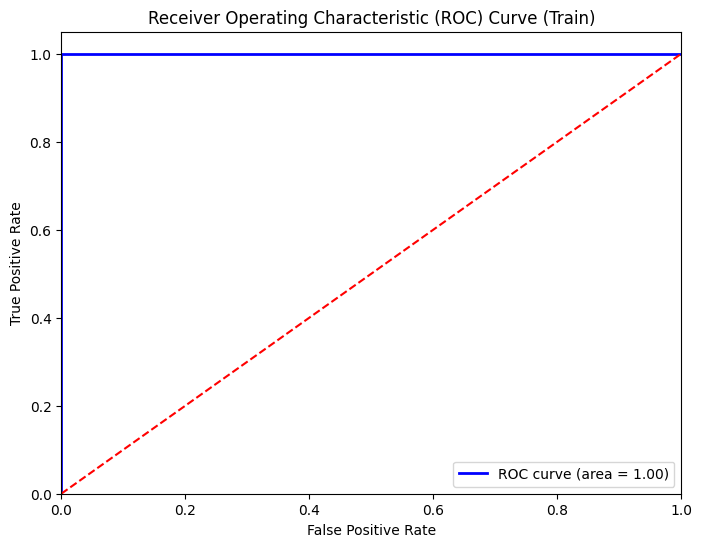

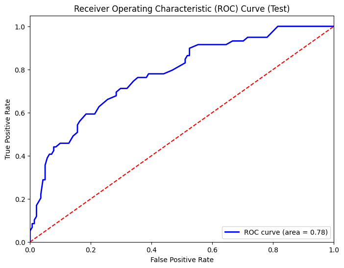

```python
# Calculate ROC curve for train set
fpr_train, tpr_train, _ = roc_curve(y_train, RF_model.predict_proba(X_train)[:,1])
roc_auc_train = auc(fpr_train, tpr_train)

# Plot ROC curve for train set
plt.figure(figsize=(8, 6))
plt.plot(fpr_train, tpr_train, color='blue', lw=2, label='ROC curve (area = %0.2f)' % roc_auc_train)
plt.plot([0, 1], [0, 1], color='red', linestyle='--')
plt.xlim([0.0, 1.0])
plt.ylim([0.0, 1.05])
plt.xlabel('False Positive Rate')
plt.ylabel('True Positive Rate')
plt.title('Receiver Operating Characteristic (ROC) Curve (Train)')
plt.legend(loc="lower right")
plt.show()

# Plot ROC curve for test set
plt.figure(figsize=(8, 6))
plt.plot(fpr, tpr, color='blue', lw=2, label='ROC curve (area = %0.2f)' % roc_auc)
plt.plot([0, 1], [0, 1], color='red', linestyle='--')
plt.xlim([0.0, 1.0])
plt.ylim([0.0, 1.05])
plt.xlabel('False Positive Rate')
plt.ylabel('True Positive Rate')
plt.title('Receiver Operating Characteristic (ROC) Curve (Test)')
plt.legend(loc="lower right")
plt.show()
```

the ROC curve for the training set is a step function and remains constant at 1, it means that the model has perfectly fit the training data, which is often an indication of overfitting. On the other hand, if the ROC curve for the test set is smooth, less rigid, and goes above the line passing through the origin, it indicates good model performance on unseen data.

**Support Vector Machines**

```python
# Initialize the Support Vector Classifier
svm_model = SVC()

# Train the model
svm_model.fit(X_train, y_train)

# Make predictions
y_pred_svm = svm_model.predict(X_test)

# Evaluate the model
accuracy_svm = accuracy_score(y_test, y_pred_svm)
print("Support Vector Machine Classifier Accuracy:", accuracy_svm)

# Classification Report
print("Classification Report:\n", classification_report(y_test, y_pred_svm))

# Confusion Matrix
print("Confusion Matrix:\n", confusion_matrix(y_test, y_pred_svm))
```

```
Support Vector Machine Classifier Accuracy: 0.745
Classification Report:
               precision    recall  f1-score   support

           0       0.78      0.89      0.83       141
           1       0.61      0.39      0.47        59

    accuracy                           0.74       200
   macro avg       0.69      0.64      0.65       200
weighted avg       0.73      0.74      0.73       200

Confusion Matrix:
 [[126  15]
 [ 36  23]]
```

**Observations**

*Accuracy:*  
The model's accuracy is 74.5%, indicating that it correctly predicts the class label for 74.5% of the samples.

*Precision:*  
For class 0 (majority class), precision is 78%, meaning that when the model predicts an instance as class 0, it is correct 78% of the time. For class 1 (minority class), precision is 61%, indicating that when the model predicts an instance as class 1, it is correct 61% of the time.

*Recall:*  
For class 0, the recall is 89%, implying that the model correctly identifies 89% of the actual class 0 instances. For class 1, the recall is 39%, meaning that the model only identifies 39% of the actual class 1 instances.

*F1-score:*  
For class 0, the F1-score is 83%, which is the harmonic mean of precision and recall for class 0. For class 1, the F1-score is 47%, which is the harmonic mean of precision and recall for class 1.

*Confusion Matrix:*  
The model predicted class 0 more accurately than class 1. There are more instances of class 1 being misclassified as class 0 (false negatives) than instances of class 0 being misclassified as class 1 (false positives).

Overall, while the model performs reasonably well in predicting non-default instances, it struggles with predicting default instances, as indicated by the lower precision, recall, and F1-score for class 1.

[figure not shown]

[figure not shown]

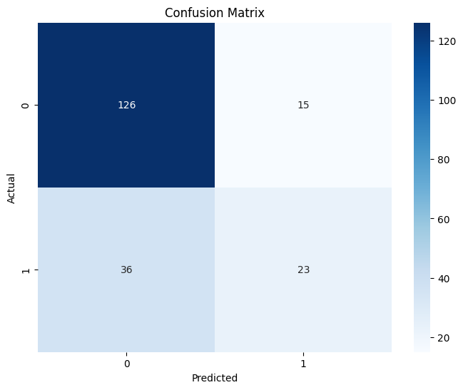

```python
# ROC curve
fpr, tpr, thresholds = roc_curve(y_test, model.predict_proba(X_test)[:, 1])
roc_auc = auc(fpr, tpr)

plt.figure(figsize=(8, 6))
plt.plot(fpr, tpr, color='blue', lw=2, label='ROC curve (area = %0.2f)' % roc_auc)
plt.plot([0, 1], [0, 1], color='red', linestyle='--')
plt.xlim([0.0, 1.0])
plt.ylim([0.0, 1.05])
plt.xlabel('False Positive Rate')
plt.ylabel('True Positive Rate')
plt.title('Receiver Operating Characteristic (ROC) Curve')
plt.legend(loc="lower right")
plt.show()

# Precision-Recall curve
precision, recall, thresholds = precision_recall_curve(y_test, model.predict_proba(X_test)[:, 1])

plt.figure(figsize=(8, 6))
plt.plot(recall, precision, color='blue', lw=2, label='Precision-Recall curve')
plt.xlabel('Recall')
plt.ylabel('Precision')
plt.title('Precision-Recall Curve')
plt.legend(loc="lower left")
plt.show()

# Plot heatmap
plt.figure(figsize=(8, 6))
sns.heatmap(confusion_matrix(y_test, y_pred_svm), annot=True, cmap='Blues', fmt='g')
plt.xlabel('Predicted')
plt.ylabel('Actual')
plt.title('Confusion Matrix')
plt.show()
```

**Gradient Boosting Classifier**

```python
# Initialize the Gradient Boosting Classifier
model = GradientBoostingClassifier()

# Train the model
model.fit(X_train, y_train)

# Predictions
y_pred = model.predict(X_test)

# Accuracy
accuracy = accuracy_score(y_test, y_pred)
print("Gradient Boosting Classifier Accuracy:", accuracy)

# Classification Report
print("Classification Report:\n", classification_report(y_test, y_pred))

# Confusion Matrix
cm = confusion_matrix(y_test, y_pred)
print("Confusion Matrix:\n", cm)
```

```
Gradient Boosting Classifier Accuracy: 0.765
Classification Report:
               precision    recall  f1-score   support

           0       0.79      0.91      0.85       141
           1       0.67      0.41      0.51        59

    accuracy                           0.77       200
   macro avg       0.73      0.66      0.68       200
weighted avg       0.75      0.77      0.75       200

Confusion Matrix:
 [[129  12]
 [ 35  24]]
```

*Accuracy:*  
The accuracy of the model is 0.765, indicating that it correctly predicts the target variable around 76.5% of the time.

*Precision and Recall:*  
Precision for class 0 (non-default) is 0.79, and for class 1 (default) is 0.67. This means that when the model predicts a non-default, it is correct 79% of the time, and when it predicts a default, it is correct 67% of the time.

Recall for class 0 is 0.91, and for class 1 is 0.41. This indicates that the model correctly identifies 91% of the non-default cases but only 41% of the default cases.

*F1-score:*  
The F1-score for class 0 is 0.85, and for class 1 is 0.51. The F1-score is the harmonic mean of precision and recall. It is a measure of a test's accuracy and is used to balance precision and recall.

The model shows decent performance, with good accuracy, precision, and recall for the majority class (non-default). However, precision and recall for the minority class (default) are relatively lower.